# Network Analysis for the mecp2 project

# Loading some pre-requisites

## Packages

```r
library(igraph)
library(ggplot2)
library(R.matlab)
```

## Aesthetics

```r
library(ggrepel) # for labelling outliers
library(ggthemes)
library(ggpubr)
library(ggsci)
th <- theme_tufte() + theme(legend.position="bottom")
colors <- scale_color_npg()
```

## Read files

```r
network <- readMat('/media/timothysit/Seagate Expansion Drive1/The_Organoid_Project/data/organoid_20180503_light/mat_files/organoid_20180503_slice1_record_2_adj.mat')
# convert from a list to a matrix
network <- matrix(unlist(network), ncol = 60, byrow = TRUE)
# Convert adjacency matrix to network object
network <- graph_from_adjacency_matrix(network, mode = "undirected", weighted = TRUE)
```

## Initial sanity check of some network values and very rough visualisation

```r
# Edge atributes
# edge_attr(network)
print("Edge weight summary:")
```

```
[1] "Edge weight summary:"
```

```r
summary(E(network)$weight)
```

```
   Min. 1st Qu.  Median    Mean 3rd Qu.    Max.    NA's
-0.0175  0.5714  0.6666  0.6368  0.7500  1.0000     702
```

```r
vertex_attr(network)
```

```
list()
```

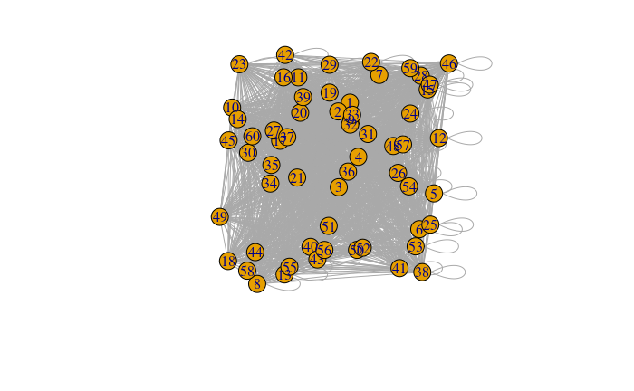

```r
plot(network)
```

Do some pre-processing and plot again:

- remove self-loops
- convert NA values to zeros
- remove numbers
- make grid layout

```r
# convert NA values ot zero
E(network)$weight[is.na(E(network)$weight)] <- 0
# remove self loops
network <- simplify(network, remove.loops = TRUE)
```

Make grid layout (for MEA data specifically)

```r
yTemp = 1:8;
# yCoord = repmat(fliplr(yTemp), 1, 8); # matlab code to be translated
yCoord = rep(rev(yTemp), 8);
xTemp = 1:8;
xCoord = rep(xTemp, each = 8);
coord = matrix(c(xCoord, yCoord), nrow = 64, ncol = 2)
# remove the 4 corners
coord <- coord[!((coord[, 1] == 1) & (coord[, 2] == 1)), ]
coord <- coord[!((coord[, 1] == 1) & (coord[, 2] == 8)), ]
coord <- coord[!((coord[, 1] == 8) & (coord[, 2] == 1)), ]
coord <- coord[!((coord[, 1] == 8) & (coord[, 2] == 8)), ]
```

Make polished plot

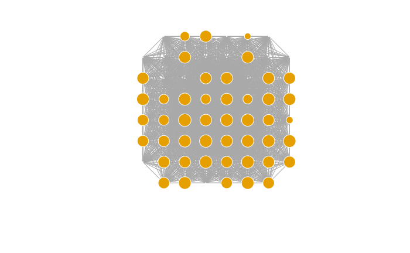

```r
# Set node size according to node strength
V(network)$size = 1 + strength(network) * 0.5
# Set node size according to node degree
# V(network.pruned)$size = 1 + igraph::degree(network.pruned) # it may be masked by the sna package
# remove vertex labels
V(network)$label <- NA
# Chane border colour
V(network)$frame.color = "white" # white, black, or grey (or NA)
plot(network, layout = coord)
```

# Single network analysis

## Thresholding to make binary network

```r
threshold <- 0.7
network.binary  <- network
network.binary <- delete_edges(network.binary, E(network.binary)[weight < threshold])
E(network.binary)$weight[E(network.binary)$weight >= threshold] <- 1
```

Plot the binary graph

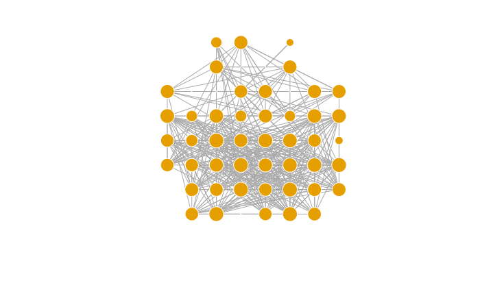

```r
plot(network.binary, layout = coord, size = 0.1 + strength(network) * 0.75)
```

## Thersholding to make pruned weighted network

## Degree distribution

For non-visualising-related analysis, it is necessary to remove nodes without any edges.

```r
# get information about the number of degrees and put that in our binary network object
V(network.binary)$degree <- degree(network.binary)
# remove vertices without edges in the binary network
network.binary <- delete_vertices(network.binary, V(network.binary)[degree == 0])
```

We can have a look at the network again, but no longer using the grid layout

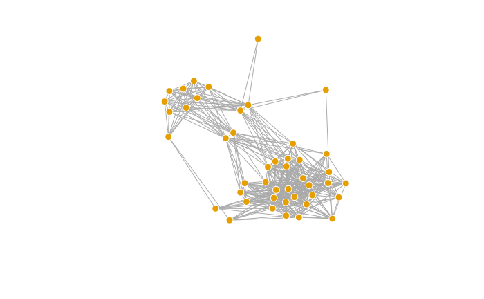

```r
plot(network.binary, vertex.size = 7.5) # note that default vertex size is 15
```

Look at degree distsribution of binary network

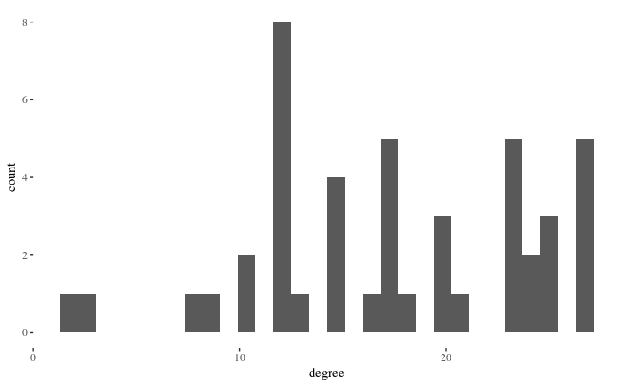

```r
df_network.binary <- data.frame("degree" = V(network.binary)$degree )
ggplot(df_network.binary, aes(x = degree)) + geom_histogram() + th + colors
```

## Weight distribution

## Network density

```r
network.binary$density <- edge_density(network.binary, loops = FALSE)
```

## Functional segregation

### Clustering coefficient

Note that the function for calculating clustering coefficient is called `transitivity` in `igraph`, and there are different options within this function that either gives you the local clustering coefficient (which you can then average for the whole graph) or the global transitivity metric.

[See here](https://stackoverflow.com/questions/48853610/average-clustering-coefficient-of-a-network-igraph)

- the “average” method (clustering coefficient) places more weight on low-degree nodes
- the transitivity method places more weight on high-degree nodes

```r
network.binary$ave_cluster_coeff <- transitivity(network.binary, type = "average", weights = NULL)
```

### Transitivity

```r
network.binary$transitivity <- transitivity(network.binary, type = "undirected", weights = NULL)
```

### Modularity

```r
network.binary$modularity <- modularity(network.binary, weights = NULL)
```

```
Error in modularity.igraph(network.binary, weights = NULL) :
  argument "membership" is missing, with no default
```

## Functional integration

### Characteristic path length and global efficiency

```r
network.binary$charPathLen <- average.path.length(network.binary, directed = FALSE)
network.binary$globalEff <- efficiency(network.binary, type = "global", weights = NULL)
```

## Small-worldness

```r
# requires qgraph
network.binary$smallwordness <- smallworldness(network.binary, B = 1000, up = 0.995, lo = 0.005)[1]
```

## Hubs and authorities

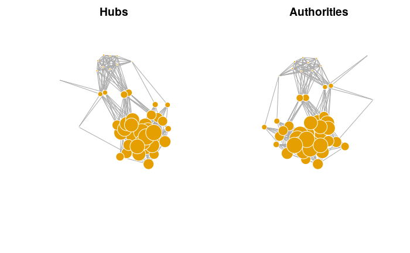

```r
hs <- hub_score(network.binary, weights=NA)$vector
as <- authority_score(network.binary, weights=NA)$vector
par(mfrow=c(1,2))
 plot(network.binary, vertex.size=hs*30, main="Hubs")
 plot(network.binary, vertex.size=as*30, main="Authorities")
```

### Rich-club coefficient

```r
network.binary$rich <- rich_club_coeff(network.binary, k = 1, weighted = FALSE) #uses brainGraph
```

## Community Detection

```r
ceb <- cluster_edge_betweenness(network.binary)
```

[output not shown]

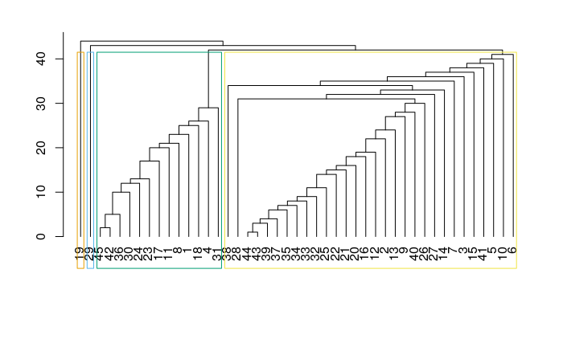

```r
dendPlot(ceb, mode="hclust")
```

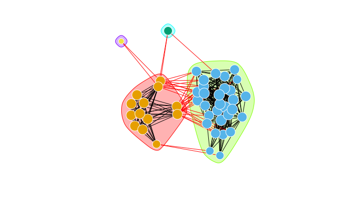

```r
plot(ceb, network.binary)
```

### Clique detection

Cliques are fully connected sub-graphs within a graph

- my interpretatoin from a functional perspective is that they may have very similar or essentially almost the same roles

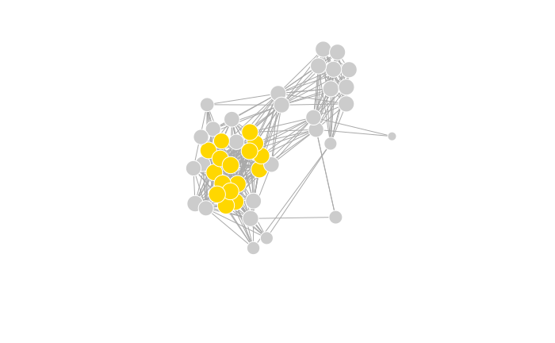

```r
vcol <- rep("grey80", vcount(network.binary))
vcol[unlist(largest_cliques(network.binary))] <- "gold"
plot(as.undirected(network.binary), vertex.label= NA, vertex.color=vcol)
```

## Centrality

### Closeness centrality

### Betwenness centrality

### Participation coefficient

## Modularty

# Summary of single network characteristics

## Radar-plot visualisations

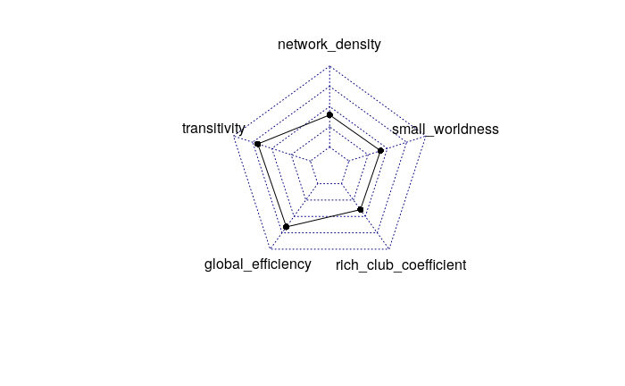

```r
library(fmsb)
# for this to work, the first row of the data fram is the ymax, the second row is the ymin
# and the third row is the final value
network_density <- c(1, 0, network.binary$density)
transitivity <- c(1, 0, network.binary$transitivity)
global_efficiency <- c(1, 0, network.binary$globalEff)
rich_club_coefficient <- c(1, 0, network.binary$rich$phi)
small_worldness <- c(3, 0, network.binary$smallwordness)
df_network.binary <- data.frame(network_density, transitivity, global_efficiency, rich_club_coefficient, small_worldness)

# The default radar chart proposed by the library:
radarchart(df_network.binary)
```

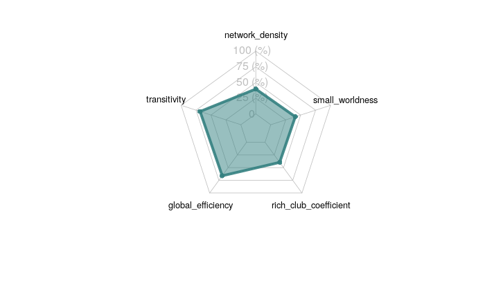

```r
# Custom the radarChart !
radarchart( df_network.binary  , axistype=1 ,

    #custom polygon
    pcol=rgb(0.2,0.5,0.5,0.9) , pfcol=rgb(0.2,0.5,0.5,0.5) , plwd=4 ,

    #custom the grid
    cglcol="grey", cglty=1, axislabcol="grey", caxislabels=seq(0,1,5), cglwd=0.8,

    #custom labels
    vlcex=0.8
    )
```

# Batch Analysis

The main idea is this:

- go to directory containing the .mat files with the adjacnecy matrices
- put them in R and convert them to igraph objects
- do thresholding / convert them to a binary graph
- calculate the network metrics and append them to a data frame
- also extract genotype and DIV data and put them to the data frame
- ideally also include the culture batch, and the ID

# Comparison of network statistics